# Assignment 2 BCB 420

Differential Gene Analysis for of NPHS2 Point Variants

Anna T. Lai

`March 13, 2024`

# Setup

```r
packages_to_install <- c("BiocManager", "RSQLite", "readr", "gplots", "reshape2", "RColorBrewer", "grid", "BiocManager", "knitr", "kableExtra", "devtools", "colorRamp2", "ggplot2")
for (package in packages_to_install) {
  if (!requireNamespace(package, quietly = TRUE)) {
    install.packages(package)
  }
  library(package, character.only = TRUE)
}

packages_to_install <- c("edgeR", "biomaRt", "GEOquery", "ComplexHeatmap")
for (package in packages_to_install) {
  if (!requireNamespace(package, quietly = TRUE)) {
    BiocManager::install(package)
  }
}

# packages_to_install <- c("crsh/citr") #Use Zotero for citation
# for (package in packages_to_install) {
#   if (!requireNamespace(package, quietly = TRUE)) {
#     devtools::install_github(package)
#   }
# }

# library(GEOmetadb) # Doesn't work anymore
library(BiocManager)
library(RSQLite)
library(readr)
library(utils)
library(base)
library(dplyr)
library(gplots)
library(reshape2)
library(RColorBrewer)
library(grid)
library(edgeR)
library(biomaRt)
library(knitr)
library(kableExtra)
library(GEOquery)
library(devtools)
library(ComplexHeatmap)
library(colorRamp2)
library(ggplot2)
```

# Information from previous assignment

About the data [1]. With reference to lecture 4 [2].

```r
data_geoid <- "GSE205647"
gse <- getGEO(data_geoid ,GSEMatrix=FALSE)
gse@header$overall_design
```

```
## [1] "Comparative gene expression profiling analysis of RNA-seq data for organoid glomeruli isolated at D7+14 from human kidney organoids with various NPHS2 homozygous point mutations."
```

Un-comment to download the files to local PC. The files are already included in the GitHub repo, just in case.There are two files in this dataset and we use the counts data.

```r
sfilenames = getGEOSuppFiles(data_geoid,
fetch_files = FALSE)
sfilenames
```

```
##                     fname
## 1 GSE205647_counts.txt.gz
## 2  GSE205647_genes.txt.gz
##                                                                                          url
## 1 https://ftp.ncbi.nlm.nih.gov/geo/series/GSE205nnn/GSE205647/suppl//GSE205647_counts.txt.gz
## 2  https://ftp.ncbi.nlm.nih.gov/geo/series/GSE205nnn/GSE205647/suppl//GSE205647_genes.txt.gz
```

```r
# Extract zipped files in the format of gz
# extract_gz <- function(file_path) {
#   message("Extracting:", basename(file_path))
#   extracted_file_name <- gsub(".gz", "", file_path)
#
#   if (!file.exists(extracted_file_name)){
#     gunzip(file_path)
#   }
# }
#

# for (filename in sfilenames$fname) {
#   file_path <- file.path(getwd(), filename)
#   if (file.exists(file_path) && file.info(file_path)$size > 0) {
#     extract_gz(file_path)
#   }
# }
```

```r
files <- c("GSE205647_counts.txt", "GSE205647_genes.txt")

counts_data <- read.table(files[1], header = TRUE)
genes_data <- read.table(files[2], header = TRUE)
```

```r
sorted_counts_data <- counts_data[order(counts_data$Gene.ID, counts_data$Chrom), ]
sorted_genes_data <- genes_data[order(genes_data$Gene.ID, genes_data$Chrom), ]

sorted_first_four_cols_of_counts_data <- sorted_counts_data[, 1:4]
names(sorted_first_four_cols_of_counts_data) <- c("Gene.ID", "Chrom", "Gene.Name", "Biotype")
names(sorted_genes_data) <- c("Gene.ID", "Chrom", "Gene.Name", "Biotype")

attr(sorted_first_four_cols_of_counts_data, "row.names") <- NULL
attr(sorted_genes_data, "row.names") <- NULL

all.equal(sorted_first_four_cols_of_counts_data, sorted_genes_data)
```

```
## [1] TRUE
```

From the above, we conclude that genes.txt. is a subset of counts.txt. We will move on to only investigate counts.txt.

#### Rename the column name for easier identification.

```r
rm_prefix <- "X211101_A01221_0077_"
rm_suffix <- "\\.20211028_TSStrmRNA$"

new_col_names <- sub(paste0("^", rm_prefix), "", colnames(counts_data))

new_col_names <- sub(rm_suffix, "", new_col_names)
colnames(counts_data) <- new_col_names
```

## Data cleaning

### Remove gene with no expression at all in all conditions; Final Coverage

```r
before_no <- dim(counts_data)[1]
selected_columns <- counts_data[, 5:ncol(counts_data)]
row_sums <- apply(selected_columns, 1, sum)
rows_to_keep <- row_sums > 1
filtered_counts_data <- counts_data[rows_to_keep,]
counts_data <- filtered_counts_data # for the ease of coding in the following sections

nrow(counts_data)
```

```
## [1] 40354
```

The number of genes remained after removing the genes without expression is 40354. Before removing genes with no expression at all is 60671. The difference is -20317.

```r
subset_data <- counts_data[, 5:ncol(counts_data)]
min_num_samples <- ncol(counts_data)/2
data_matrix <- as.matrix(subset_data)

keep = rowSums(cpm(data_matrix) >1) > min_num_samples
filtered_data_matrix= data_matrix[keep,]
counts_data <- counts_data[keep,]

nrow(counts_data)
```

```
## [1] 15865
```

Choose min number of samples to roughly half of the column numbers so that there’s some comparison. This reduced the number of genes of interest to 15865. This is my final coverage.

### Investigate gene dupication in the file

```r
# print duplicate count by Gene.ID
duplicates_count <- counts_data%>%
  group_by(Gene.ID) %>%
  mutate(duplicate_count = n()) %>%
  filter(duplicate_count > 1)

print(nrow(duplicates_count))
```

```
## [1] 0
```

```r
# print duplicate count by Gene.Name
duplicates_count <- counts_data %>%
  group_by(Gene.Name, Chrom) %>%
  mutate(duplicate_count = n()) %>%
  filter(duplicate_count > 1) %>%
  summarize(duplicate_count = n_distinct(Gene.ID))%>%
  arrange(desc(duplicate_count))
duplicates_count
```

```
## # A tibble: 6 × 3
## # Groups:   Gene.Name [6]
##   Gene.Name  Chrom duplicate_count
##   <chr>      <chr>           <int>
## 1 DNAJC9-AS1 10                  2
## 2 HSPA14     10                  2
## 3 POLR2J4    7                   2
## 4 RGS5       1                   2
## 5 SPATA13    13                  2
## 6 TBCE       1                   2
```

```r
length(unique(duplicates_count$Gene.Name))
```

```
## [1] 6
```

From the above we see that there is no gene with the same Ensembl ID. Each of them are unique. However, there are 6 genes duplicates when grouped by gene symbol. Upon further investigation, some of the gene are located at a different chromosome, hence, the number of duplication of gene paired chromosome location is calculated. The number is 6.

### Visualizations

```r
biotype_tabulation <- table(counts_data$Biotype)
biotype_df <- data.frame(Biotype = names(biotype_tabulation), Count = as.vector(biotype_tabulation))

biotype_df<- biotype_df %>%
  arrange(desc(Count))

biotype_df %>%
  kable(caption = "Descending Sorting by Count") %>%
  kable_styling(position = "center")
```

Descending Sorting by Count

| Biotype | Count |
| --- | --- |
| protein_coding | 5061 |
| processed_transcript | 3962 |
| retained_intron | 3735 |
| lncRNA | 1529 |
| nonsense_mediated_decay | 679 |
| processed_pseudogene | 587 |
| transcribed_unprocessed_pseudogene | 90 |
| TEC | 89 |
| transcribed_processed_pseudogene | 49 |
| unprocessed_pseudogene | 43 |
| transcribed_unitary_pseudogene | 9 |
| miRNA | 7 |
| non_stop_decay | 5 |
| misc_RNA | 4 |
| Mt_rRNA | 2 |
| pseudogene | 2 |
| snoRNA | 2 |
| TR_V_gene | 2 |
| IG_C_pseudogene | 1 |
| Mt_tRNA | 1 |
| polymorphic_pseudogene | 1 |
| snRNA | 1 |
| TR_C_gene | 1 |
| TR_J_gene | 1 |
| translated_processed_pseudogene | 1 |
| unitary_pseudogene | 1 |

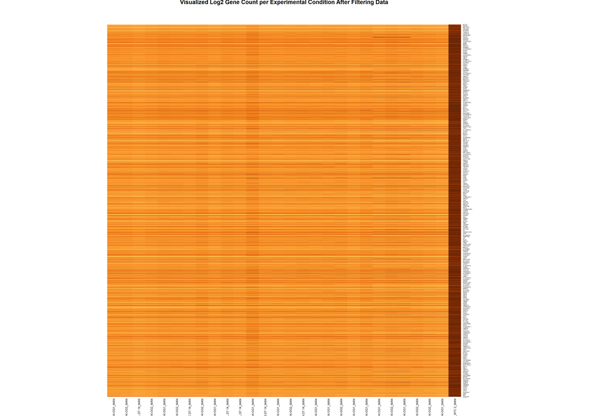

```r
# Subset the data
subset_data <- counts_data[, 5:ncol(counts_data)]
rownames(subset_data) <- counts_data$Gene.ID

ds <- data.frame(subset_data)
rn <- counts_data[,3]
cn <- colnames(subset_data)
x <- data.matrix(ds, rownames.force = FALSE)

par(fig = c(0, 1, 0, 1), mar = c(5.1, 4.1, 4.1, 8.1))
x_log <- log2(x)
x_log[which(x_log == -Inf)] <- 0

hm <- heatmap(x_log, Rowv = NA, Colv = NA, margins = c(5, 10), col = colorRampPalette(rev(brewer.pal(9, "YlOrBr")))(256), scale = "none", dendrogram = "none", xlab = "", ylab = "", main = "Visualized Log2 Gene Count per Experimental Condition After Filtering Data", labRow = rn, labCol = cn)
```

Expression of the genes for the last condition is low in general. Since we removed the genes with low count, all the rows look pretty active. Condition 8, 12, 21 seems to have lower expression level then all other conditions.

```r
colnames(counts_data)[8]
```

```
## [1] "ML215213_AD2141.808.5.CTL.D7.14.OG2_MAN"
```

```r
colnames(counts_data)[12]
```

```
## [1] "ML215217_AD2124.G92C.D7.14.OG2_MAN"
```

```r
colnames(counts_data)[21]
```

```
## [1] "ML215226_AD2145.R168H.D7.14.OG1_MAN"
```

```r
colnames(counts_data)[31]
```

```
## [1] "ML215236_AD2121.R168H.RG.Pro.D7.14.OG1_MAN"
```

Box plot with reference with lecture 5 normalization codes after data filtering.

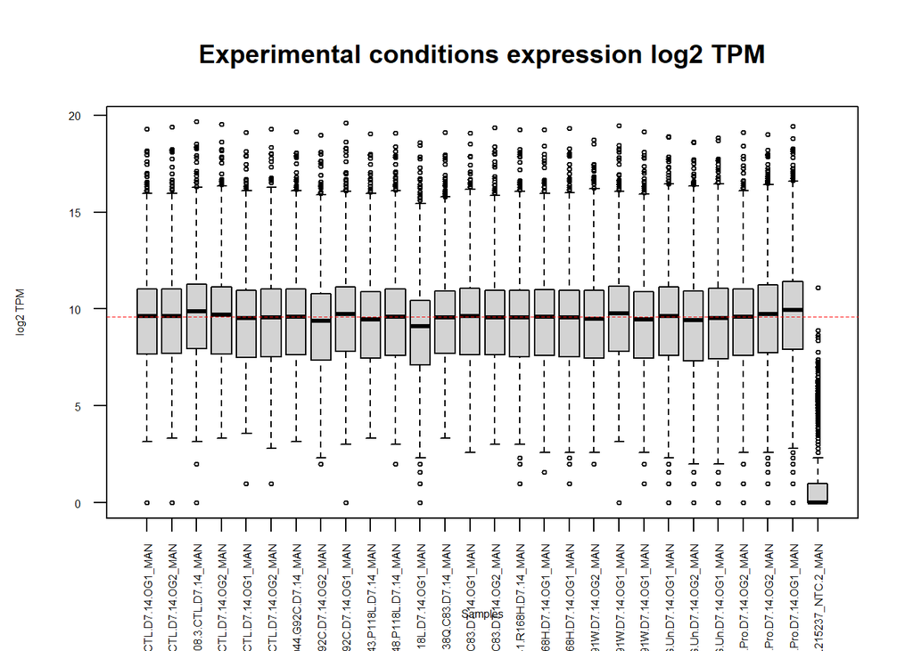

```r
boxplot(x_log, xlab = "Samples", ylab = "log2 TPM",
las = 2, cex = 0.5, cex.lab = 0.5,
cex.axis = 0.5, main = "Experimental conditions expression log2 TPM")

abline(h = median(apply(x_log, 2, median)),
col = "red", lwd = 0.6, lty = "dashed")
```

Density plot with reference to lecture 5 normalization codes. Before normalization.

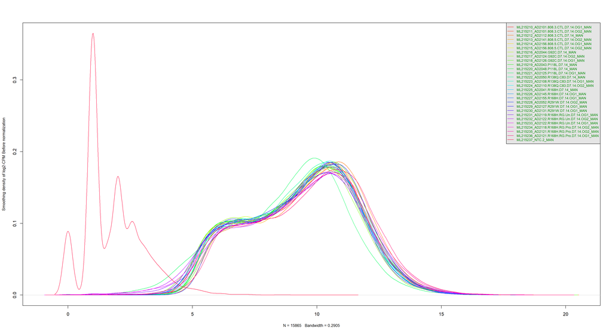

```r
counts_density <- apply(log2(subset_data), 2, density)

xlim <- 0; ylim <- 0
for (i in 1:length(counts_density)) {
xlim <- range(c(xlim, counts_density[[i]]$x));
ylim <- range(c(ylim, counts_density[[i]]$y))
}
cols <- rainbow(length(counts_density))
ltys <- rep(1, length(counts_density))


plot(counts_density[[1]], xlim=xlim, ylim=ylim, type="n",
ylab="Smoothing density of log2-CPM Before normalization",
main="", cex.lab = 0.85)

for (i in 1:length(counts_density))
lines(counts_density[[i]], col=cols[i], lty=ltys[i])
#create legend
legend("topright", colnames(subset_data),
col=cols, lty=ltys, cex=0.75,
border ="blue", text.col = "green4",
merge = TRUE, bg = "gray90")
```

It seems like my data does not follow a normal distribution, rather, an anti-symmetry distribution is observed.There is a sample that lies completely to the left side. Perhaps it is the NTC sample.

## Data Normalization

### Apply Trimmed Mean of M-values to counts_data based on Samples

With reference to lecture 5.

Data grouping according to sample. Added cell line from Assignment 1 for investigation.

```r
sample_groups <- unlist(lapply(c(rep("808.3", 3), rep("808.5", 3), rep("G92C", 3), rep("P118L", 3), rep("R138Q", 3), rep("R168H.D7.14", 3), rep("R291W", 3), rep("R168H.RG.Un", 3), rep("R168H.RG.Pro", 3)), identity))
sample_groups <- append(sample_groups, "NTC")

rep <- rep(c(1, 2, 3), times = 9)
rep <- append(rep, 1)

cell_line <- unlist(lapply(c(rep("iPSC", 21), rep("Human Sample", 6)), identity))
cell_line <- append(cell_line, "iPSC")

exp_groups <- cbind(colnames(subset_data), sample_groups, rep, cell_line)

exp_groups <- data.frame(sample_group = sample_groups, replication = rep, cell_line=cell_line)
exp_groups
```

```
##    sample_group replication    cell_line
## 1         808.3           1         iPSC
## 2         808.3           2         iPSC
## 3         808.3           3         iPSC
## 4         808.5           1         iPSC
## 5         808.5           2         iPSC
## 6         808.5           3         iPSC
## 7          G92C           1         iPSC
## 8          G92C           2         iPSC
## 9          G92C           3         iPSC
## 10        P118L           1         iPSC
## 11        P118L           2         iPSC
## 12        P118L           3         iPSC
## 13        R138Q           1         iPSC
## 14        R138Q           2         iPSC
## 15        R138Q           3         iPSC
## 16  R168H.D7.14           1         iPSC
## 17  R168H.D7.14           2         iPSC
## 18  R168H.D7.14           3         iPSC
## 19        R291W           1         iPSC
## 20        R291W           2         iPSC
## 21        R291W           3         iPSC
## 22  R168H.RG.Un           1 Human Sample
## 23  R168H.RG.Un           2 Human Sample
## 24  R168H.RG.Un           3 Human Sample
## 25 R168H.RG.Pro           1 Human Sample
## 26 R168H.RG.Pro           2 Human Sample
## 27 R168H.RG.Pro           3 Human Sample
## 28          NTC           1         iPSC
```

```r
d = DGEList(counts=as.matrix(subset_data), group=exp_groups$sample_groups)
d = calcNormFactors(d)
normalized_count_data <- cpm(d)
```

Box plot with reference with lecture 5 normalization codes after normalization. The median aligned together except for the last condition NTC. Normalization successfully applied to the data.

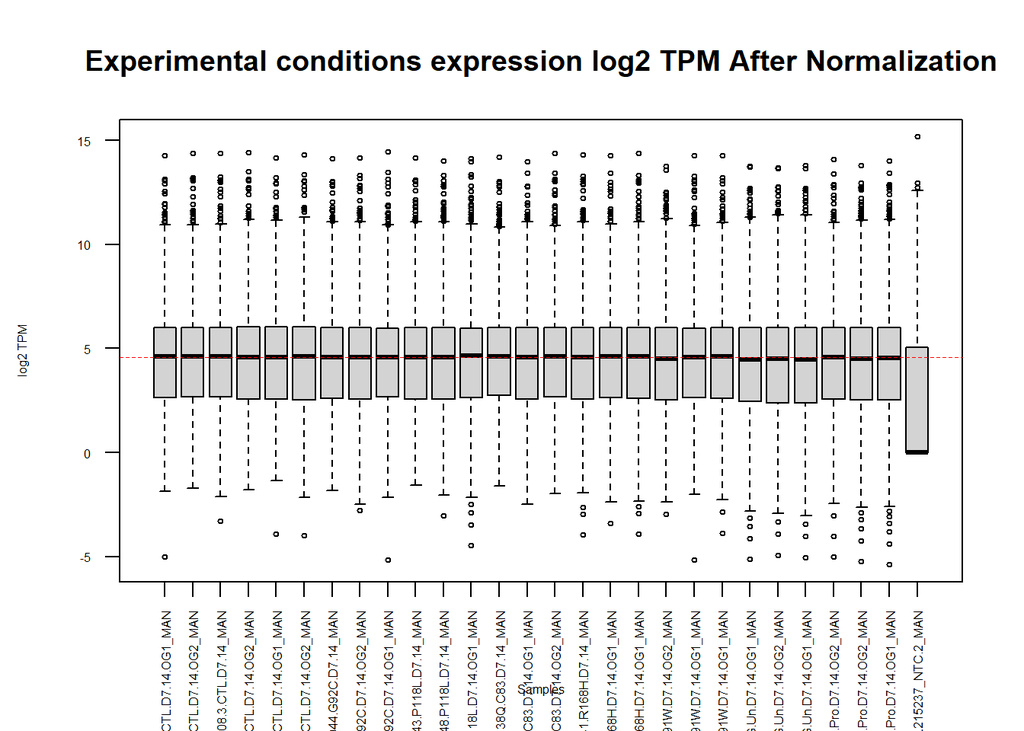

```r
x_log <- log2(normalized_count_data)
x_log[which(x_log == -Inf)] <- 0

boxplot(x_log, xlab = "Samples", ylab = "log2 TPM",
las = 2, cex = 0.5, cex.lab = 0.5,
cex.axis = 0.5, main = "Experimental conditions expression log2 TPM After Normalization")

abline(h = median(apply(x_log, 2, median)),
col = "red", lwd = 0.6, lty = "dashed")
```

Density plot with reference to lecture 5 normalization codes.

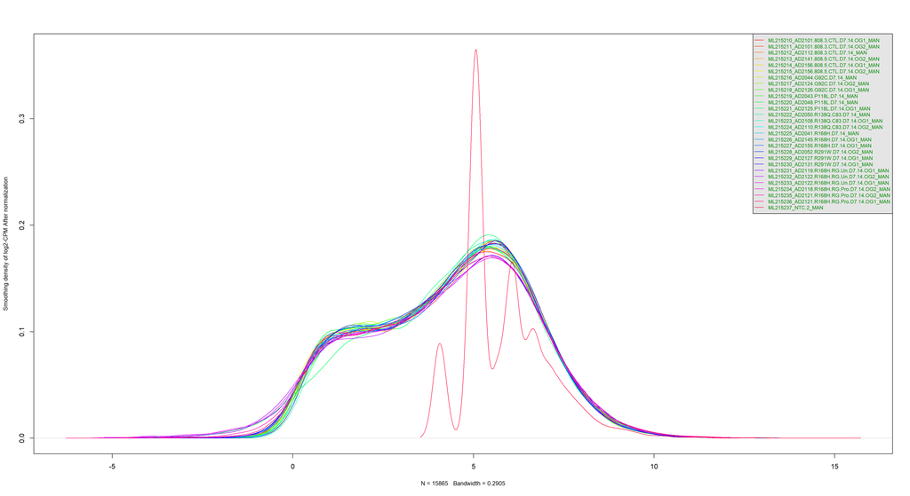

```r
counts_density <- apply(log2(normalized_count_data), 2, density)

xlim <- 0; ylim <- 0
for (i in 1:length(counts_density)) {
xlim <- range(c(xlim, counts_density[[i]]$x));
ylim <- range(c(ylim, counts_density[[i]]$y))
}
cols <- rainbow(length(counts_density))
ltys <- rep(1, length(counts_density))


plot(counts_density[[1]], xlim=xlim, ylim=ylim, type="n",
ylab="Smoothing density of log2-CPM After normalization",
main="", cex.lab = 0.85)

for (i in 1:length(counts_density))
lines(counts_density[[i]], col=cols[i], lty=ltys[i])
#create legend
legend("topright", colnames(subset_data),
col=cols, lty=ltys, cex=0.75,
border ="blue", text.col = "green4",
merge = TRUE, bg = "gray90")
```

The data looks more centered after normalization.

# Continued Data Exloration Journey

### MDS plot

I have not included this plot in the previous assignment.Plotted with reference to lecture 5.

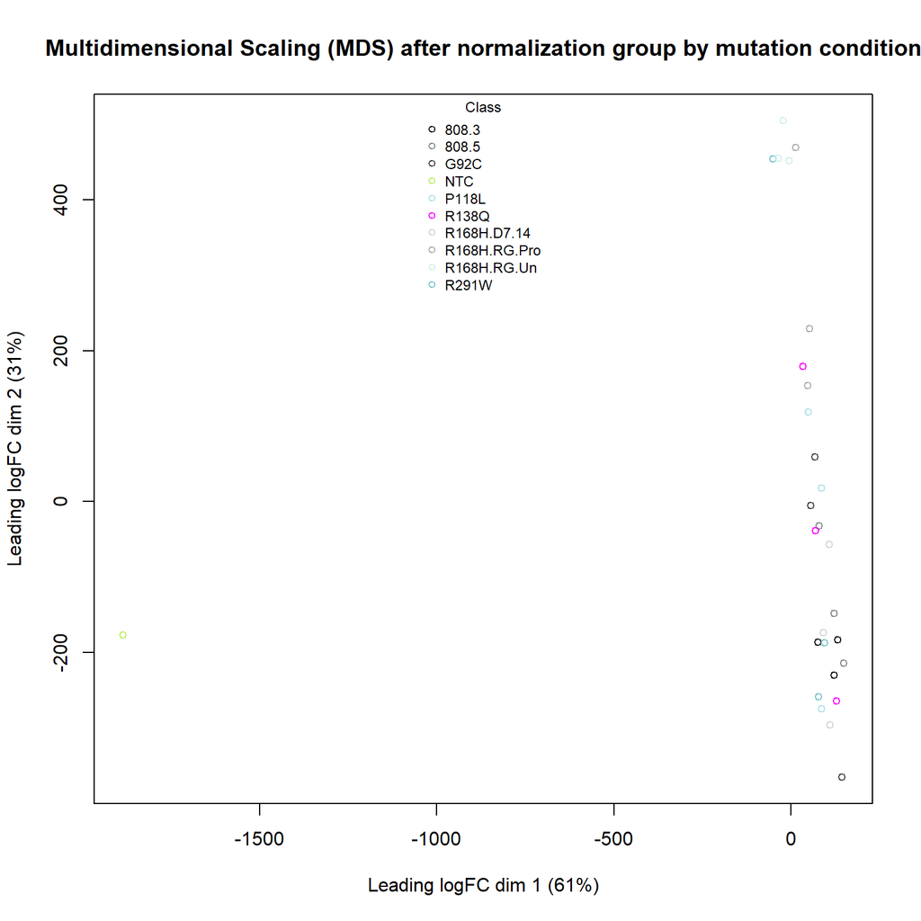

```r
colors_plot<- sample(colors()[1:657], 10)

limma::plotMDS(normalized_count_data, labels=NULL,pch=1, cex=0.8,
col = colors_plot[factor(exp_groups$sample_group)], main = "Multidimensional Scaling (MDS) after normalization group by mutation condition")

legend("top",
legend=levels(factor(exp_groups$sample_group)),
pch=c(1), col=
colors_plot,title="Class",
bty = 'n', cex = 0.75)
```

The data is separted into NTC and non NTC according to the MDS graph.

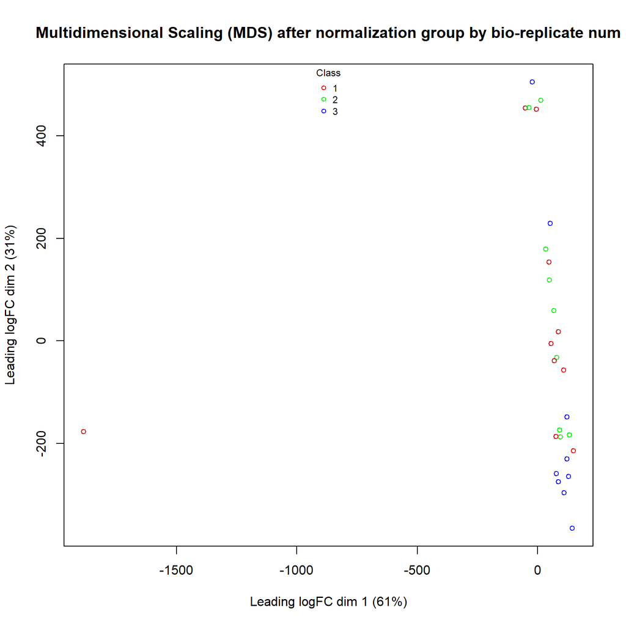

```r
colors_plot<- c("red3", "green2", "blue2")
limma::plotMDS(normalized_count_data, labels=NULL,pch=1, cex=0.8,
col = colors_plot[factor(exp_groups$replication)], main = "Multidimensional Scaling (MDS) after normalization group by bio-replicate num")

legend("top",
legend=levels(factor(exp_groups$replication)),
pch=c(1), col=
colors_plot,title="Class",
bty = 'n', cex = 0.75)
```

No significant difference showned. The 1 at the left hand side is of type NTc.

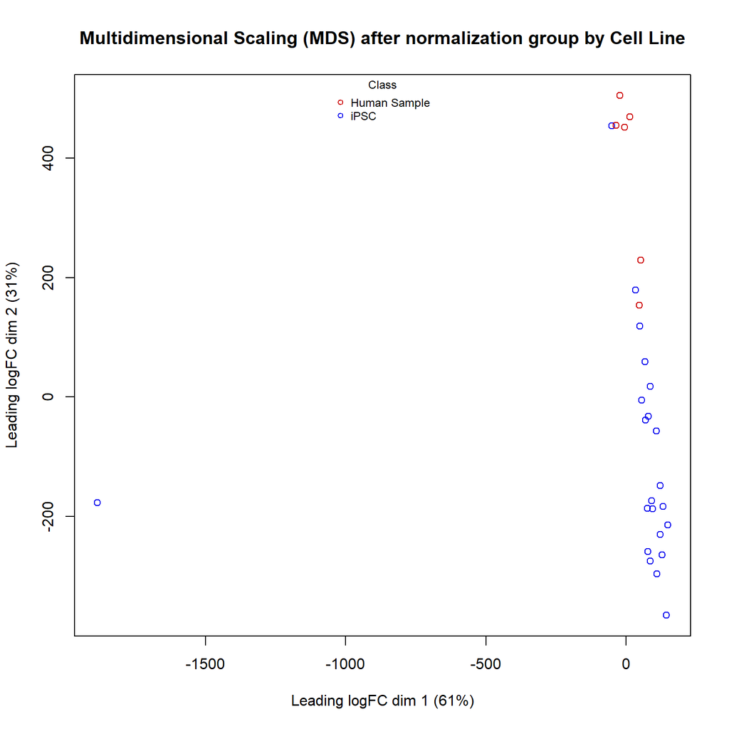

```r
colors_plot<- c("red3", "blue2")

limma::plotMDS(normalized_count_data, labels=NULL,pch=1, cex=1,
col = colors_plot[factor(exp_groups$cell_line)], main = "Multidimensional Scaling (MDS) after normalization group by Cell Line")

legend("top",
legend=levels(factor(exp_groups$cell_line)),
pch=c(1), col=
colors_plot,title="Class",
bty = 'n', cex = 0.75)
```

## Differential Gene Expression

### Limma p-value method.

```r
model_design <- model.matrix(~exp_groups$sample_group)

expressionMatrix <- as.matrix(normalized_count_data)
rownames(expressionMatrix) < counts_data$Gene.ID
colnames(expressionMatrix) <- colnames(normalized_count_data)
minimalSet <- ExpressionSet(assayData=expressionMatrix)

fit <- lmFit(minimalSet, model_design)
fit2 <- eBayes(fit,trend=TRUE)

topfit <- topTable(fit2,
coef=ncol(model_design),
adjust.method = "BH",
number = nrow(expressionMatrix))


output_hits <- merge(data.frame(counts_data$Gene.ID, counts_data$Gene.Name), topfit, by.y=0, by.x=1, all.y=TRUE)
output_hits <- output_hits[order(output_hits$P.Value),]
```

```r
kable(head(output_hits),type="html",row.names = FALSE)
```

| counts_data.Gene.ID | counts_data.Gene.Name | logFC | AveExpr | t | P.Value | adj.P.Val | B |
| --- | --- | --- | --- | --- | --- | --- | --- |
| ENSG00000250486 | FAM218A | 5.222809 | 3.872693 | 8.012058 | 1.00e-07 | 0.0007831 | 1.3753412 |
| ENSG00000081842 | PCDHA6 | 3.167206 | 2.765361 | 7.999076 | 1.00e-07 | 0.0007831 | 1.3684445 |
| ENSG00000198829 | SUCNR1 | -22.607208 | 11.174006 | -7.140723 | 6.00e-07 | 0.0029661 | 0.8695681 |
| ENSG00000171466 | ZNF562 | 17.940683 | 30.710344 | 6.510113 | 2.10e-06 | 0.0084879 | 0.4442186 |
| ENSG00000164756 | SLC30A8 | 3.148058 | 3.705150 | 6.304536 | 3.30e-06 | 0.0106253 | 0.2938270 |
| ENSG00000101194 | SLC17A9 | -3.570288 | 3.391808 | -5.383355 | 2.65e-05 | 0.0700646 | -0.4551752 |

```r
length(which(output_hits$P.Value < 0.05)) # passed p-value<0.05 threshold
```

```
## [1] 833
```

```r
length(which(output_hits$adj.P.Val < 0.05)) # passed adjacent f-value < 0.05 threshold
```

```
## [1] 5
```

Model 2 with cell line as variable that is taken into consideration

```r
model_design2 <- model.matrix(~exp_groups$cell_line)
fit_pat <- lmFit(minimalSet, model_design2)
fit_pat2 <- eBayes(fit_pat,trend=TRUE)

topfit <- topTable(fit_pat2,
coef=ncol(model_design2),
adjust.method = "BH",
number = nrow(expressionMatrix))


output_hits2 <- merge(data.frame(counts_data$Gene.ID, counts_data$Gene.Name), topfit, by.y=0, by.x=1, all.y=TRUE)
output_hits2 <- output_hits2[order(output_hits2$P.Value),]
```

```r
kable(head(output_hits2),type="html",row.names = FALSE)
```

| counts_data.Gene.ID | counts_data.Gene.Name | logFC | AveExpr | t | P.Value | adj.P.Val | B |
| --- | --- | --- | --- | --- | --- | --- | --- |
| ENSG00000280670 | CCDC163 | -10.871277 | 4.002954 | -29.39147 | 0 | 0 | 8.730198 |
| ENSG00000110628 | SLC22A18 | -19.222296 | 10.594833 | -18.58167 | 0 | 0 | 7.720209 |
| ENSG00000164305 | CASP3 | -37.417945 | 42.721646 | -17.27606 | 0 | 0 | 7.481602 |
| ENSG00000169908 | TM4SF1 | -58.495369 | 24.713568 | -16.19720 | 0 | 0 | 7.248811 |
| ENSG00000236682 | MAP3K2-DT | -8.821201 | 5.573572 | -14.27491 | 0 | 0 | 6.730627 |
| ENSG00000185596 | WASH3P | -17.423192 | 11.583019 | -14.25695 | 0 | 0 | 6.725039 |

```r
length(which(output_hits2$P.Value < 0.05)) # passed p-value<0.05 threshold
```

```
## [1] 5349
```

```r
length(which(output_hits2$adj.P.Val < 0.05)) # passed adjacent f-value < 0.05 threshold
```

```
## [1] 3608
```

A lot more genes pass the threshold using this model. However, the context of using condition to group makes more sense for our purposes.

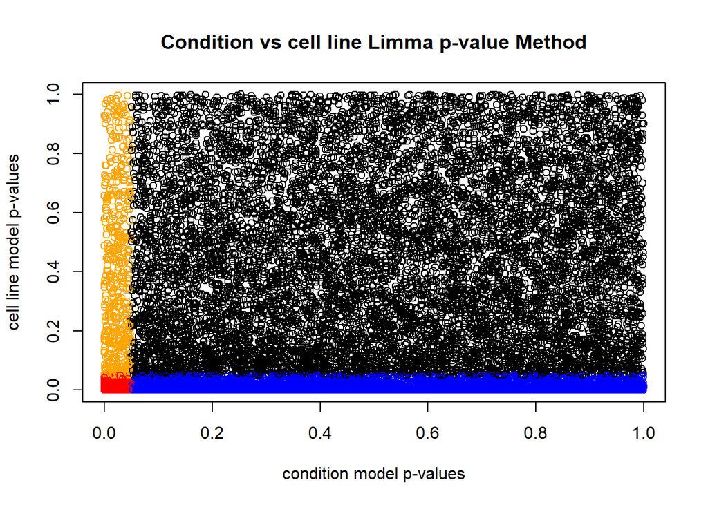

```r
model1_pvalues <- data.frame(
  ensembl_id =output_hits$counts_data.Gene.ID,
simple_pvalue=output_hits$P.Value)

model2_pvalues <- data.frame(
  ensembl_id =output_hits2$counts_data.Gene.ID,
patient_pvalue = output_hits2$P.Value)

two_models_pvalues <- merge(model1_pvalues,
model2_pvalues,by.x=1,by.y=1)
two_models_pvalues$colour <- "black"
two_models_pvalues$colour[
two_models_pvalues$simple_pvalue<0.05] <- "orange"
two_models_pvalues$colour[
two_models_pvalues$patient_pvalue<0.05] <- "blue"
two_models_pvalues$colour[
two_models_pvalues$simple_pvalue<0.05 &
two_models_pvalues$patient_pvalue<0.05] <- "red"

plot(two_models_pvalues$simple_pvalue,
two_models_pvalues$patient_pvalue,
col = two_models_pvalues$colour,
xlab = "condition model p-values",
ylab ="cell line model p-values",
main="Condition vs cell line Limma p-value Method")
```

BH was used as it is the most generic method that applies to most type of data distributions.

```r
p.adjust.methods
```

```
## [1] "holm"       "hochberg"   "hommel"     "bonferroni" "BH"
## [6] "BY"         "fdr"        "none"
```

### EdgeR Quasi liklihood model

```r
d = DGEList(counts=minimalSet, group = exp_groups$sample_group)
d <- estimateDisp(d, model_design)
fit <- glmQLFit(d, model_design)

fitting_primary_vs_recurrent <- glmQLFTest(fit)

qlf_output_hits <- topTags(fitting_primary_vs_recurrent,
sort.by = "PValue",
n = nrow(minimalSet),
adjust.method = "BH"
)

kable(head(qlf_output_hits$table), caption="Quasi Liklihood method results group by condition type") %>% kableExtra::kable_styling()
```

Quasi Liklihood method results group by condition type

|  | logFC | logCPM | F | PValue | FDR |
| --- | --- | --- | --- | --- | --- |
| ENSG00000236539 | 2.6381098 | 2.506548 | 39.52163 | 2.60e-06 | 0.0232634 |
| ENSG00000250486 | 5.4181464 | 2.550044 | 135.33124 | 3.30e-06 | 0.0232634 |
| ENSG00000162779 | 1.8130640 | 5.861298 | 36.68749 | 4.40e-06 | 0.0232634 |
| ENSG00000261250 | 1.6505348 | 5.294973 | 28.17922 | 2.56e-05 | 0.0852855 |
| ENSG00000198829 | -1.9913497 | 3.721822 | 27.96756 | 2.69e-05 | 0.0852855 |
| ENSG00000171466 | 0.8903473 | 5.026182 | 44.55556 | 5.57e-05 | 0.1473618 |

Number of genes that passed the 0.05 p-value threshold. Only 336 genes are significantly differential expressed. Number of genes that passed the correlation

```r
length(which(qlf_output_hits$table$PValue < 0.05))
```

```
## [1] 336
```

```r
length(which(qlf_output_hits$table$FDR < 0.05))
```

```
## [1] 3
```

Repeat the same process, but group by cell line type.

```r
d = DGEList(counts=minimalSet, group = exp_groups$cell_line)
d <- estimateDisp(d, model_design2)
fit <- glmQLFit(d, model_design2)

fitting_primary_vs_recurrent <- glmQLFTest(fit)

qlf_output_hits2 <- topTags(fitting_primary_vs_recurrent,
sort.by = "PValue",
n = nrow(minimalSet),
adjust.method = "BH"
)

kable(head(qlf_output_hits2$table), caption="Quasi Liklihood method results group by cell line") %>% kableExtra::kable_styling()
```

Quasi Liklihood method results group by cell line

|  | logFC | logCPM | F | PValue | FDR |
| --- | --- | --- | --- | --- | --- |
| ENSG00000280670 | -2.7462053 | 2.576396 | 312.6848 | 0 | 0 |
| ENSG00000164305 | -0.9746731 | 5.474699 | 181.3320 | 0 | 0 |
| ENSG00000203666 | 1.1648697 | 5.059722 | 152.1981 | 0 | 0 |
| ENSG00000204792 | 6.4353184 | 3.617376 | 142.5663 | 0 | 0 |
| ENSG00000211445 | -1.4870475 | 8.566543 | 123.2424 | 0 | 0 |
| ENSG00000132205 | -1.4359990 | 5.469047 | 123.1160 | 0 | 0 |

Genes are significantly more deferentially expressed under different cell line. The sample might not be a good representation of the target study group, or it could be the other way round, the iPSC cell line is not a good presentation of the target study group.

```r
length(which(qlf_output_hits2$table$PValue < 0.05)) # pvalue threshold
```

```
## [1] 4194
```

```r
length(which(qlf_output_hits2$table$FDR < 0.05)) # correlation
```

```
## [1] 2483
```

Compare the results of the p-value methods for condition grouping.

[figure not shown]

```r
qlf_pat_model_pvalues <- data.frame(
ensembl_id = rownames(qlf_output_hits$table),
qlf_patient_pvalue=qlf_output_hits$table$PValue)

limma_pat_model_pvalues <- data.frame(
ensembl_id = output_hits$counts_data.Gene.ID,
limma_patient_pvalue = output_hits$P.Value)

two_models_pvalues <- merge(qlf_pat_model_pvalues,
limma_pat_model_pvalues,
by.x=1,by.y=1)
two_models_pvalues$colour <- "black"
two_models_pvalues$colour[two_models_pvalues$qlf_patient_pvalue
<0.05] <- "orange"
two_models_pvalues$colour[two_models_pvalues$limma_patient_pvalue
<0.05] <- "blue"
two_models_pvalues$colour[two_models_pvalues$qlf_patient_pvalue
<0.05 &
two_models_pvalues$limma_patient_pvalue<0.05] <- "red"

two_models_pvalues_subset <-
two_models_pvalues[which(two_models_pvalues$colour != "black"),]

plot(two_models_pvalues_subset$qlf_patient_pvalue,
two_models_pvalues_subset$limma_patient_pvalue,
col = two_models_pvalues_subset$colour,
xlab = "QLF patient model p-values - only significant",
ylab ="Limma Patient model p-values Comparison results",
main="QLF vs Limma group by condition")

legend_labels <- levels(factor(two_models_pvalues$colour))
legend("topright", legend=c("N/A","qlf_patient_pvalue", "both", "limma_patient_pvalue"), fill=unique(two_models_pvalues$colour), cex=0.8)
```

Compare the results of the p-value for cell line grouping.

[figure not shown]

```r
qlf_pat_model_pvalues <- data.frame(
ensembl_id = rownames(qlf_output_hits2$table),
qlf_patient_pvalue=qlf_output_hits2$table$PValue)

limma_pat_model_pvalues <- data.frame(
ensembl_id = output_hits2$counts_data.Gene.ID,
limma_patient_pvalue = output_hits2$P.Value)

two_models_pvalues <- merge(qlf_pat_model_pvalues,
limma_pat_model_pvalues,
by.x=1,by.y=1)
two_models_pvalues$colour <- "black"
two_models_pvalues$colour[two_models_pvalues$qlf_patient_pvalue
<0.05] <- "orange"
two_models_pvalues$colour[two_models_pvalues$limma_patient_pvalue
<0.05] <- "blue"
two_models_pvalues$colour[two_models_pvalues$qlf_patient_pvalue
<0.05 &
two_models_pvalues$limma_patient_pvalue<0.05] <- "red"

two_models_pvalues_subset <-
two_models_pvalues[which(two_models_pvalues$colour != "black"),]

plot(two_models_pvalues_subset$qlf_patient_pvalue,
two_models_pvalues_subset$limma_patient_pvalue,
col = two_models_pvalues_subset$colour,
xlab = "QLF patient model p-values - only significant",
ylab ="Limma Patient model p-values Comparison results",
main="QLF vs Limma group by cell line")

egend_labels <- levels(factor(two_models_pvalues$colour))
legend("topright", legend=c("N/A","qlf_patient_pvalue", "both", "limma_patient_pvalue"), fill=unique(two_models_pvalues$colour), cex=0.8)
```

## Volcano Plot For down regualred versus up regulated genes

Number of Up-regualted versus down regulated gene sets resulted from Tophis in Quasi

```r
length(which(qlf_output_hits$table$PValue < 0.05
& qlf_output_hits$table$logFC > 0))
```

```
## [1] 109
```

```r
length(which(qlf_output_hits$table$PValue < 0.05
& qlf_output_hits$table$logFC < 0))
```

```
## [1] 227
```

Created with reference to online resources [3].

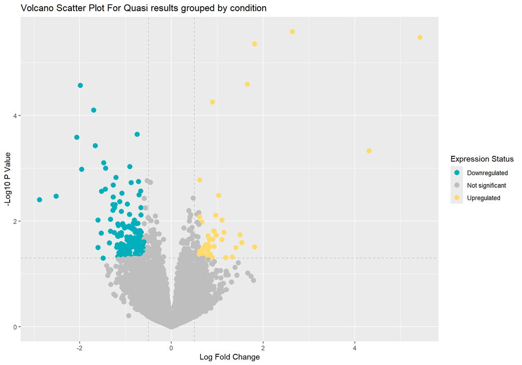

```r
# Create a basic volcano plot

volcano_qlf_output_hits <- qlf_output_hits
volcano_qlf_output_hits$table$diffexpressed <- "NO"

volcano_qlf_output_hits$table$diffexpressed[volcano_qlf_output_hits$table$logFC > 0.6 & volcano_qlf_output_hits$table$PValue < 0.05] <- "UP"

volcano_qlf_output_hits$table$diffexpressed[volcano_qlf_output_hits$table$logFC< -0.6 & volcano_qlf_output_hits$table$PValue < 0.05] <- "DOWN"

ggplot2::ggplot(
  data = qlf_output_hits$table,
  aes(x = qlf_output_hits$table$logFC,
      y = -log10(qlf_output_hits$table$PValue),
      col = volcano_qlf_output_hits$table$diffexpressed)

  ) +
  geom_point() +
  geom_vline(xintercept = c(-0.5, 0.5), col = "gray", linetype = 'dashed')+
  geom_hline(yintercept = -log10(0.05), col = "gray", linetype = 'dashed') +
  geom_point(size = 3)+
  scale_color_manual(values = c("#00AFBB", "grey", "#FFDB6D"),
                     labels = c("Downregulated", "Not significant", "Upregulated"))+
  labs(title = "Volcano Scatter Plot For Quasi results grouped by condition",
     x = "Log Fold Change",
     y = "-Log10 P Value",
     color = "Expression Status")
```

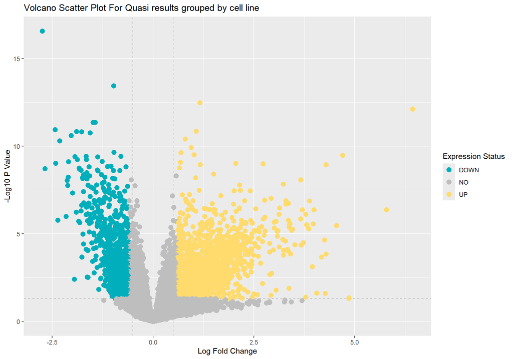

```r
volcano_qlf_output_hits2 <- qlf_output_hits2
volcano_qlf_output_hits2$table$diffexpressed <- "NO"

volcano_qlf_output_hits2$table$diffexpressed[volcano_qlf_output_hits2$table$logFC > 0.6 & volcano_qlf_output_hits2$table$PValue < 0.05] <- "UP"

volcano_qlf_output_hits2$table$diffexpressed[volcano_qlf_output_hits2$table$logFC< -0.6 & volcano_qlf_output_hits2$table$PValue < 0.05] <- "DOWN"

# volcano_qlf_output_hits2$table$diffexpressed[rownames(volcano_qlf_output_hits2$table) == "ENSG00000116218"] <- "NPHS2"

ggplot2::ggplot(
  data = volcano_qlf_output_hits2$table,
  aes(x = qlf_output_hits2$table$logFC,
      y = -log10(qlf_output_hits2$table$PValue),
      col = volcano_qlf_output_hits2$table$diffexpressed)

  ) +
  geom_point() +
  geom_vline(xintercept = c(-0.5, 0.5), col = "gray", linetype = 'dashed')+
  geom_hline(yintercept = -log10(0.05), col = "gray", linetype = 'dashed') +
  geom_point(size = 3)+
  scale_color_manual(values = c("#00AFBB", "grey", "#FFDB6D", "black"),
                     labels = c("DOWN", "NO", "UP", "NPHS2"))+
  labs(title = "Volcano Scatter Plot For Quasi results grouped by cell line",
     x = "Log Fold Change",
     y = "-Log10 P Value",
     color = "Expression Status")
```

In the paper, the gene NPHS2 ENSG00000116218 was the gene of interest and under modification in their study.

```r
qlf_output_hits$table[rownames(qlf_output_hits$table) == "ENSG00000116218", ]
```

```
##                      logFC   logCPM        F    PValue       FDR
## ENSG00000116218 -0.1191618 10.23732 0.122093 0.7301218 0.9999033
```

```r
qlf_output_hits2$table[rownames(qlf_output_hits2$table) == "ENSG00000116218", ]
```

```
##                     logFC   logCPM      F     PValue        FDR
## ENSG00000116218 -1.019125 10.23617 11.384 0.00208064 0.01903653
```

### Top hit genes Heatmap of the Quasi liklihood method

Completed with reference to Lecture 7 [4].

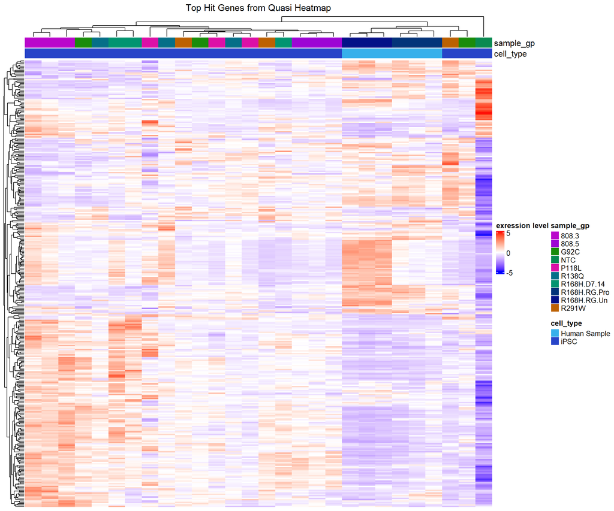

```r
# prepare for heatmap
top_hits <- rownames(qlf_output_hits$table)[
qlf_output_hits$table$PValue<0.05]

heatmap_matrix_tophits <- t(
scale(t(expressionMatrix[which(rownames(expressionMatrix) %in% top_hits),])))

# Top annotation
unique_sample_group <- unique(exp_groups$patient)
unique_sample_groupcolors <- rainbow(n = length(unique_sample_group))
names(unique_sample_groupcolors) <- unique_sample_group

unique_cell_line <- unique(exp_groups$cell_line)
unique_cell_linecolors <- rainbow(n = length(unique_cell_line))
names(unique_cell_linecolors) <- unique_cell_line

ha_pat <- HeatmapAnnotation(df = data.frame(
sample_gp = exp_groups$sample_group,
cell_type = exp_groups$cell_line),
col = list(
sample_group = unique_sample_groupcolors,
tumor_type = unique_cell_linecolors),
show_legend = TRUE)

# draw heatmap
if(min(heatmap_matrix_tophits) == 0){
heatmap_col = colorRamp2(c( 0, max(heatmap_matrix_tophits)),
c( "white", "red"))
} else {
heatmap_col = colorRamp2(c(min(heatmap_matrix_tophits), 0,
max(heatmap_matrix_tophits)),
c("blue", "white", "red"))
}

num_colors <- length(unique(exp_groups$sample_group))
color_vector <- heat.colors(num_colors)

current_heatmap <- ComplexHeatmap::Heatmap(as.matrix(heatmap_matrix_tophits),
name = "exression level",
cluster_rows = TRUE,
cluster_columns = TRUE,
show_row_dend = TRUE,
show_column_dend = TRUE,
col=heatmap_col,
show_column_names = FALSE,
show_row_names = FALSE,
show_heatmap_legend = TRUE,
column_title = "Top Hit Genes from Quasi Heatmap",
top_annotation = ha_pat
)# Heatmap

current_heatmap
```

## Thresholded over-representation analysis (ORA)

Create the list Code developed with reference to lecture 8 [5] .

```r
#merge gene names with the top hits
# the Threshold used is Quasi.
qlf_output_hits_withgn <- merge(counts_data[,c("Gene.ID", "Gene.Name")], qlf_output_hits, by.x=1, by.y = 0)

qlf_output_hits_withgn[,"rank"] <- log(qlf_output_hits_withgn$PValue,base =10) * sign(qlf_output_hits_withgn$logFC)

qlf_output_hits_withgn <- qlf_output_hits_withgn[order(qlf_output_hits_withgn$rank),]

write.table(x=data.frame(genename= qlf_output_hits_withgn$Gene.Name, F_stat= qlf_output_hits_withgn$rank),
file=file.path(getwd(),"primary_vs_recurrent_ranked_genelist.txt"), sep = "\t",row.names = FALSE, col.names = FALSE,quote = FALSE)
```

Create list of up-regulated genes and down-regulated genes. Make them available for download and perform enrichment analysis with the file.

```r
upregulated_genes <- qlf_output_hits_withgn$Gene.Name[ which(qlf_output_hits_withgn$PValue < 0.05 & qlf_output_hits_withgn$logFC > 0)]
downregulated_genes <- qlf_output_hits_withgn$Gene.Name[ which(qlf_output_hits_withgn$PValue < 0.05 & qlf_output_hits_withgn$logFC < 0)]

write.table(x=upregulated_genes, file=file.path(getwd(),"ovrecurrent_upregulated_genes.txt"), sep = "\t",row.names = FALSE, col.names = FALSE,quote = FALSE)
write.table(x=downregulated_genes, file=file.path(getwd(),"ovrecurrent_downregulated_genes.txt"), sep = "\t",row.names = FALSE, col.names = FALSE,quote = FALSE)
```

### Method chosen

I decided to use g:profiler [6] for enrichment analysis.

Parameter used:

- Significance Threshold: FER
- User threshold: 0.05
- Gene Ontology: GO Molecular Function, GO Biological Process, Reactome

### All Differentially Expressed Genes

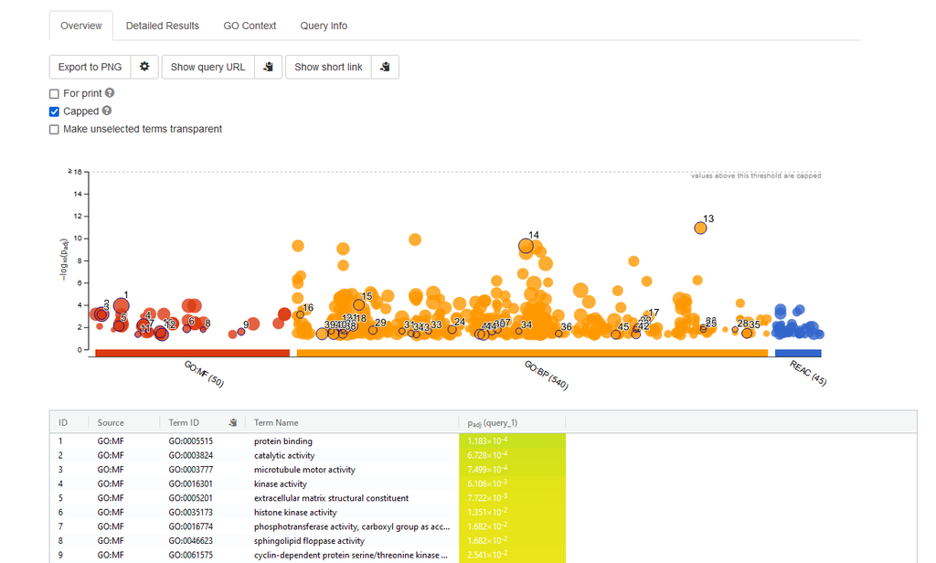

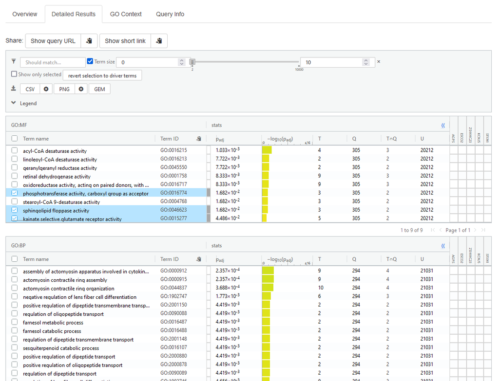

[figure not shown]

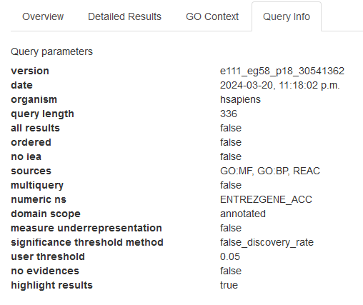

### Up-Regualted Genes

[figure not shown]

[figure not shown]

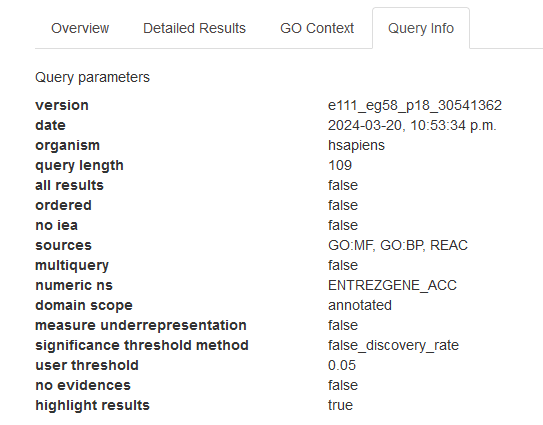

Caption: Paremeters used.

### Down-Regualted Genes

There are way more down-regulated genes than up regulated genes.

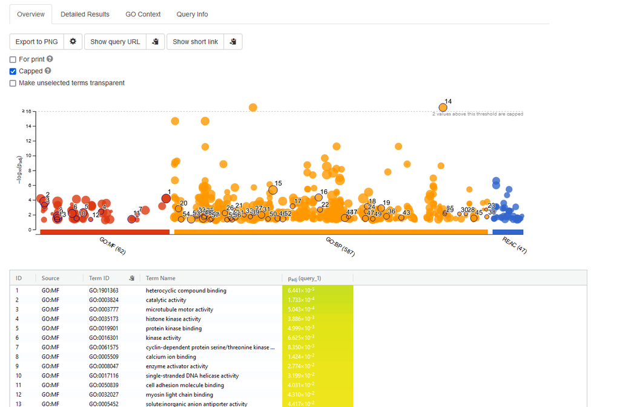

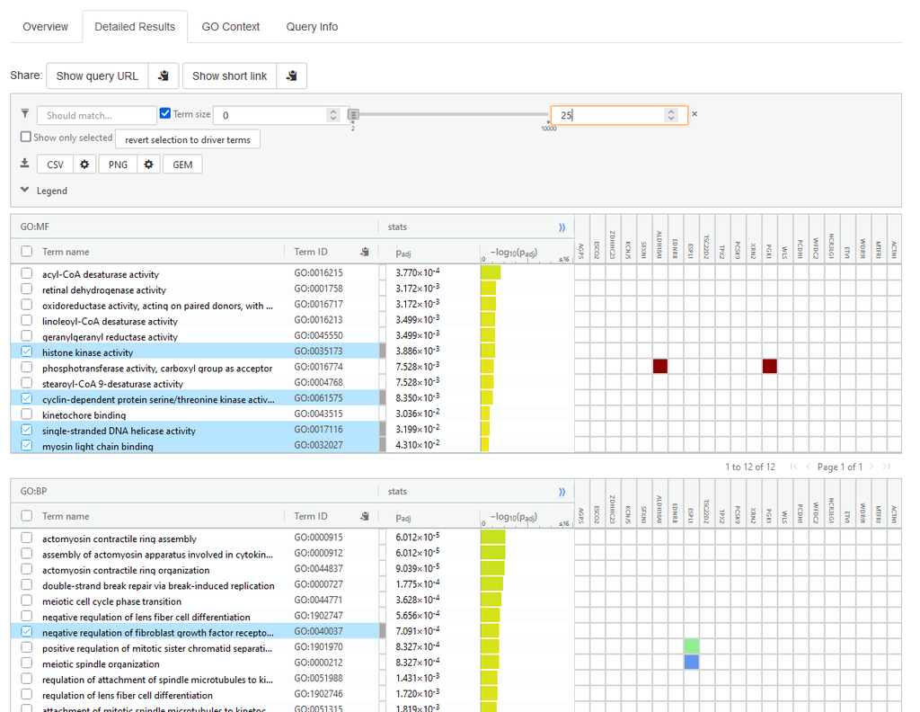

Down regulated genes are mostly involved with GO:BP: actomyosin contractile ring assembly, REAC: Condensation of Prometaphase Chromosomes.

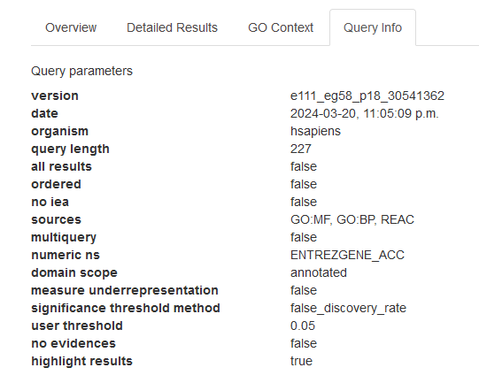

Caption: Paremeters used.

## Intrepretation - Questions and answers

#### 1. Do the over-representation results support conclusions or mechanism discussed in the original paper?

The key findings of the paper suggest that the NPHS2 variant lines resulted in reduced functional PODOCIN protein despite reduced the level of PODOCIN protein transcription remained the same, the localization of the mutated PODOCIN protein, namely P118L and R138Q were retained in Endoplasmic Reticulum (ER); R168 and R291 were retained in the Golgi apparatus.

There is not direct inducation on the regulation of genes in cell cycle, mitotic, G2/M, or DNA replication checkpoint, actomyosin contractile ring assembly and chromosome condensation genes or pathways.

#### 2. Can you find evidence, i.e. publications, to support some of the results that you see. How does this evidence support your results.

Upond further research, it is noted that downregulation of genes involved in actomyosin contractile ring assembly and chromosome condensation is particularly concerning with previous findings confirming the potential pathway, as it indicates potential impairment of critical podocyte functions. This could contribute to the development of proteinuria and progression to focal segmental glomerulosclerosis (FSGS) observed in patients with NPHS2 variants [7].

Focal segmental glomerulosclerosis (FSGS) can be caused by mutations in the genes NPHS2, ACTN4, TRPC6, and INF2 among others, presenting variable levels of proteinuria, including nephrotic syndrome, that frequently progress to end-stage renal disease (ESRD) [7].

## Citations

1. Dorison A, Ghobrial I, Graham A, Peiris T, Forbes TA, See M, et al. [Kidney organoids generated using an allelic series of NPHS2 point variants reveal distinct intracellular podocin mistrafficking](https://doi.org/10.1681/ASN.2022060707). J Am Soc Nephrol. 2023;34:88–109.

2. Isserlin R. BCB420 - computational systems biology lecture 4 getting the data. 2024.

3. Volcano plots in r: Easy step-by-step tutorial - biostatsquid.com. 2022. http://volcano-plot-r-tutorial. Accessed 16 Mar 2024.

4. Isserlin R. BCB420 - computational systems biology lecture 7 intro to heatmaps. 2024.

5. Isserlin R. BCB420 - computational systems biology lecture 8 intro to pathway analysis. 2024.

6. Raudvere U, Kolberg L, Kuzmin I, Arak T, Adler P, Peterson H, et al. [G:profiler: A web server for functional enrichment analysis and conversions of gene lists (2019 update)](https://doi.org/10.1093/nar/gkz369). Nucleic Acids Research. 2019;47:W191–8.

7. [Effect of combined NPHS2 and ACTN4 variants in the onset and severity of focal segmental glomerulosclerosis](https://www.rarediseasesjournal.com/public/index.php/articles/effect-of-combined-nphs2-and-actn4-variants-in-the-onset-and-severity-of-focal-segmental-glomerulosclerosis.html). Journal of Rare Diseases Research & Treatment. 2022;7.

8. Isserlin R. BCB420 - computational systems biology lecture 7 differential expression. 2024.

9. Isserlin R. BCB420 - computational systems biology lecture 7 annotation datasets. 2024.

10. GEOquery. Bioconductor. http://bioconductor.org/packages/GEOquery/. Accessed 16 Mar 2024.

11. GEO accession viewer. https://www.ncbi.nlm.nih.gov/geo/query/acc.cgi?acc=GSE205647. Accessed 16 Mar 2024.

12. Gene: NPHS2 (ENSG00000116218) - summary - homo_sapiens - ensembl genome browser 111. http://useast.ensembl.org/Homo_sapiens/Gene/Summary?db=core;g=ENSG00000116218;r=1:179550539-179575952. Accessed 16 Mar 2024.

13. Enrichment map analysis pipeline. https://baderlab.github.io/Cytoscape_workflows/EnrichmentMapPipeline/Protocol2_createEM.html. Accessed 20 Mar 2024.

14. Enrichment map analysis pipeline. https://baderlab.github.io/Cytoscape_workflows/EnrichmentMapPipeline/Protocol2_createEM.html. Accessed 20 Mar 2024.